# Covariates in a model-based meta-analysis

# The unifying model

One model is fitted to all three studies. It starts away from every generating model, so nothing is being handed the answer.

```r
mod_unify <- function() {
  ini({lcl <- log(2.0); lv <- log(30); clwt <- 0.50; clcr <- 0.25
       eta.cl ~ 0.20; prop.err <- 0.25})
  model({cl <- exp(lcl + eta.cl) * (WT / 70)^clwt * (CRCL / 95)^clcr
         v  <- exp(lv)
         d/dt(centr) <- -cl / v * centr
         cp <- centr / v
         cp ~ prop(prop.err)})
}
```

# Fitting: two estimators, ordinary and reweighted

`adgh` integrates the covariate on a deterministic product grid; `admc` integrates it by simulating subjects. `cov_reweight = TRUE` changes how that integral is evaluated in both: the covariate is carried in an importance weight rather than in the grid or the sample, so `adgh` drops the covariate dimension from its grid and `admc` shares one simulation ensemble across studies that differ only in their covariate distribution.

It is opt-in and self-declining. The substitution it relies on — that the prediction depends on the covariate and the random effect only through their sum — is a property of the model, and it is checked numerically once per fit rather than inferred from how the model is written. Anything that fails the check keeps the ordinary path, so the flag can only make a qualifying fit cheaper.

```r
fit_one <- function(studies, est, reweight) {
  ctl <- if (est == "adgh")
    adghControl(studies = studies, n_nodes = 7L, print = 0L,
                covMethod = "none", maxeval = 400L, cov_reweight = reweight)
  else
    admControl(studies = studies, n_sim = 3000L, print = 0L,
               covMethod = "none", maxeval = 400L, cov_reweight = reweight)
  t0 <- Sys.time()
  f  <- try(suppressWarnings(suppressMessages(
    nlmixr2est::nlmixr2(mod_unify, admData(), est = est, control = ctl))),
    silent = TRUE)
  dt <- as.numeric(difftime(Sys.time(), t0, units = "secs"))
  if (inherits(f, "try-error")) {
    ## Distinguish a DELIBERATE refusal from a failure. Labelling both "refused"
    ## would present a bug as a design decision, which is the more dangerous of
    ## the two ways to be wrong here.
    msg <- conditionMessage(attr(f, "condition"))
    st  <- if (grepl("does not support|cannot represent|joint", msg))
      "refused" else paste0("ERROR: ", substr(msg, 1, 90))
    return(data.frame(estimator = est, reweight = reweight, status = st,
                      lcl = NA, lv = NA, clwt = NA, clcr = NA,
                      objective = NA, secs = dt))
  }
  ax <- f$env$admExtra
  data.frame(estimator = est, reweight = reweight, status = "fitted",
             lcl = unname(ax$struct[["lcl"]]), lv = unname(ax$struct[["lv"]]),
             clwt = unname(ax$struct[["clwt"]]),
             clcr = unname(ax$struct[["clcr"]]),
             objective = f$objective, secs = dt)
}
```

## Version 0 — independent margins

```r
studies_indep <- make_studies(WT_INDEP)
```

[output not shown]

```r
grid1 <- expand.grid(est = c("adgh", "admc"), rw = c(FALSE, TRUE),
                     stringsAsFactors = FALSE)
res0 <- do.call(rbind, Map(function(e, r)
  fit_one(studies_indep, e, r), grid1$est, grid1$rw))
knitr::kable(res0, digits = 4, row.names = FALSE,
             caption = "Independent covariate margins. Both estimators apply, and reweighting reproduces the unweighted answer.")
```

Independent covariate margins. Both estimators apply, and reweighting reproduces the unweighted answer.

| estimator | reweight | status | lcl | lv | clwt | clcr | objective | secs |
| --- | --- | --- | --- | --- | --- | --- | --- | --- |
| adgh | FALSE | fitted | 1.1525 | 3.0342 | 0.7630 | 0.4494 | -610.6688 | 8.3135 |
| admc | FALSE | fitted | 1.1514 | 3.0342 | 0.7613 | 0.4488 | -610.6600 | 18.9994 |
| adgh | TRUE | fitted | 1.1525 | 3.0342 | 0.7630 | 0.4494 | -610.6688 | 5.0106 |
| admc | TRUE | fitted | 1.1514 | 3.0342 | 0.7613 | 0.4488 | -610.6600 | 18.7003 |

## Version 1 — summary statistics

```r
res1 <- do.call(rbind, Map(function(e, r)
  fit_one(studies_summary, e, r), grid1$est, grid1$rw))
knitr::kable(res1, digits = 4, row.names = FALSE,
             caption = "Three studies described by summary statistics.")
```

Three studies described by summary statistics.

| estimator | reweight | status | lcl | lv | clwt | clcr | objective | secs |
| --- | --- | --- | --- | --- | --- | --- | --- | --- |
| adgh | FALSE | refused | NA | NA | NA | NA | NA | 0.1221 |
| admc | FALSE | fitted | 1.1519 | 3.0342 | 0.7603 | 0.4496 | -588.2404 | 18.9393 |
| adgh | TRUE | refused | NA | NA | NA | NA | NA | 0.1251 |
| admc | TRUE | fitted | 1.1519 | 3.0342 | 0.7603 | 0.4496 | -588.2404 | 19.0199 |

## Version 2 — R-vine copulas

```r
studies_vine <- make_studies(WT_VINE)
```

[output not shown]

```r
res2 <- do.call(rbind, Map(function(e, r)
  fit_one(studies_vine, e, r), grid1$est, grid1$rw))
knitr::kable(res2, digits = 4, row.names = FALSE,
             caption = "The same three studies with an R-vine copula per study. `adgh` refuses a joint sampler by design: its covariate grid is a tensor product of per-covariate quadratures, which *is* the independence assumption, so it cannot represent a dependent distribution and declines rather than integrating the wrong one.")
```

The same three studies with an R-vine copula per study. `adgh` refuses a joint sampler by design: its covariate grid is a tensor product of per-covariate quadratures, which *is* the independence assumption, so it cannot represent a dependent distribution and declines rather than integrating the wrong one.

| estimator | reweight | status | lcl | lv | clwt | clcr | objective | secs |
| --- | --- | --- | --- | --- | --- | --- | --- | --- |
| adgh | FALSE | refused | NA | NA | NA | NA | NA | 0.1204 |
| admc | FALSE | fitted | 1.1521 | 3.0342 | 0.76 | 0.4496 | -593.2502 | 52.1218 |
| adgh | TRUE | refused | NA | NA | NA | NA | NA | 0.1148 |
| admc | TRUE | fitted | 1.1521 | 3.0342 | 0.76 | 0.4496 | -593.2502 | 51.5776 |

# Act I: what the analysis is actually given

The three studies have to differ in their covariate distributions for the coefficients to be estimable at all, and the two dependent versions have to actually carry dependence. Both are worth seeing rather than asserting.

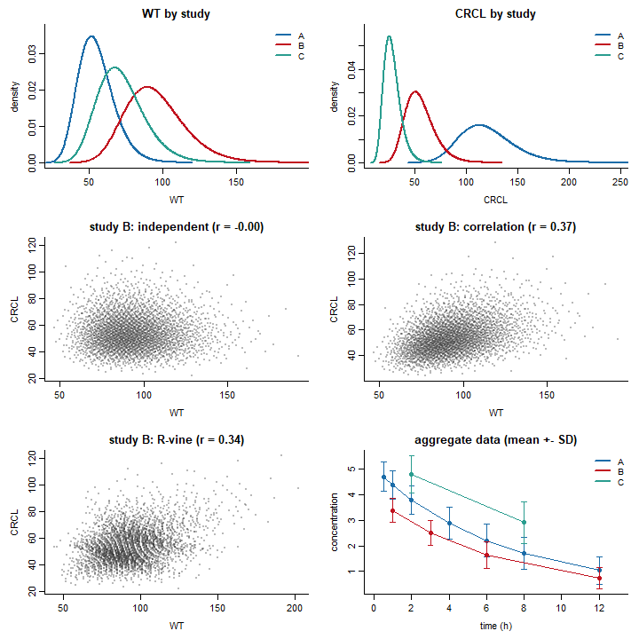

The marginals differ between studies, which is what makes the coefficients estimable; the independent version shows no tilt, and both dependent versions do.

# Act II: what the fits concluded

Each fit is summarised by what it says about clearance: how it scales with weight at a typical creatinine clearance, and with creatinine clearance at a typical weight. The three generating models are drawn for comparison — there is no single truth here, since the unifying model is one structure reconciling three, so the generating curves bracket rather than define the answer.

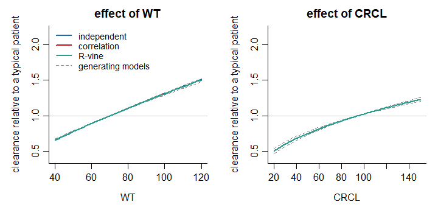

Estimated covariate exponents against the average of the three generating models.

| description | clwt | clcr | clwt vs 0.75 | clcr vs 0.45 |
| --- | --- | --- | --- | --- |
| independent | 0.763 | 0.449 | +2% | -0% |
| correlation | 0.760 | 0.450 | +1% | -0% |
| R-vine | 0.760 | 0.450 | +1% | -0% |

Both coefficients come back close to the models that generated them, and — more usefully — they barely move between the three covariate descriptions. How the covariates are described, and whether their dependence is modelled at all, shifts the estimates by less than the generating models differ from each other.

That is the robustness result. It is also not automatic, and the next section is about what makes it hold.

# Act III: why this works, and when it would not

The coefficients come back close to the models that generated them, which is not automatic — it is a property of this study set, and it is worth knowing which property.

A covariate slope is learned two ways, and they are very unequal. *Within* a study it enters through the variance, because the spread of weights and renal function among that study’s subjects inflates the observed covariance. That is weak information. *Between* studies it enters through the mean levels, which is strong — but it is also exactly where a difference in baseline clearance would land. Three studies and three parameters means the between-study system is exactly determined, so any baseline disagreement is absorbed by the slopes rather than resisted.

What protects this analysis is that the covariate contrast is far larger than the disagreement it has to survive. Creatinine clearance runs from 28 to 120 across the three studies — a factor of four — while the models themselves agree to within about 6%.

And “disagreement” means EVERY parameter the unifying model collapses to one, not just baseline clearance. Volume, the random-effect magnitude and the residual error are equally between-study quantities with a single value in the unifying model, so a volume disagreement loads onto the covariate slopes exactly as a clearance disagreement does. An earlier version of this vignette had the three models differing by a third in volume while agreeing to 6% on clearance, and that alone put both exponents about 50% high — with the renal contrast already in place. The quantity that matters is total disagreement against covariate leverage, and it is easy to control for the parameter you happen to be thinking about while leaving the others free.

Take that away and the same machinery gives a different answer. The right-hand panel below is the same three designs with creatinine clearance varying by 13% between studies instead of fourfold, and baseline clearances spread over 50% instead of 6%. Every study still has a slope near 0.45, and the fitted slope is 1.41.

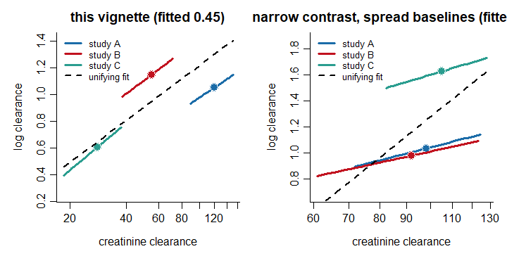

The cleanest version of the same point removes the disagreement entirely. Below, all three studies are generated from ONE model — same `lcl`, same coefficients — and differ only in their design and their covariate distribution, which is what the coefficients are supposed to be estimated from.

```r
mod_common <- function() {
  ini({lcl <- log(3.2); lv <- log(21); clwt <- 0.75; clcr <- 0.45
       eta.cl ~ 0.09; prop.err <- 0.13})
  model({cl <- exp(lcl + eta.cl) * (WT / 70)^clwt * (CRCL / 95)^clcr
         v  <- exp(lv)
         d/dt(centr) <- -cl / v * centr
         cp <- centr / v
         cp ~ prop(prop.err)})
}
studies_common <- datagen(
  setNames(lapply(names(DESIGN), function(k)
    list(model = mod_common, times = DESIGN[[k]]$times, ev = DESIGN[[k]]$ev,
         n = DESIGN[[k]]$n, cov_dist = WT_INDEP[[k]])), names(DESIGN)),
  control = datagenControl(n_sim = 30000L, seed = 4321L))
```

[output not shown]

```r
fit_c <- suppressWarnings(suppressMessages(nlmixr2est::nlmixr2(
  mod_unify, admData(), est = "adgh",
  control = adghControl(studies = studies_common, n_nodes = 7L, print = 0L,
                        covMethod = "none", maxeval = 2000L))))
ax <- fit_c$env$admExtra
knitr::kable(data.frame(
  parameter = c("lcl", "clwt", "clcr"),
  truth     = c(log(3.2), 0.75, 0.45),
  estimate  = c(ax$struct[["lcl"]], ax$struct[["clwt"]], ax$struct[["clcr"]])),
  digits = 4, row.names = FALSE,
  caption = "Three studies from ONE generating model, differing only in design and covariate distribution.")
```

Three studies from ONE generating model, differing only in design and covariate distribution.

| parameter | truth | estimate |
| --- | --- | --- |
| lcl | 1.1632 | 1.1632 |
| clwt | 0.7500 | 0.7501 |
| clcr | 0.4500 | 0.4501 |

Every parameter comes back exactly, which is the reference point: with nothing disagreeing between studies there is nothing for the slopes to absorb, and the estimator recovers what generated the data.

The practical reading is that a covariate coefficient estimated across studies carries whatever else differs between those studies. It is trustworthy to the extent that the covariate contrast is large compared with those differences — here a fourfold renal range against 6% baseline disagreement — and it stops being trustworthy when that ratio reverses, whether the analysis is of aggregate data or of individual records.

# What to take away

The estimates agree across every cell that runs. That is the point of the comparison: the four combinations evaluate the same integral by different means, so agreement is evidence that the integral, and not the machinery, is what determines the answer.

Reweighting is a speed setting, not a modelling choice. It changes how the covariate integral is evaluated and nothing about what is being estimated, which is why the estimates match rather than merely resemble each other.

`adgh` and a dependent covariate distribution do not combine. That is a refusal and not a limitation to work around: a product grid assumes independence, and producing a number from it would be worse than declining. Use `admc` when the covariates are dependent.

Finally, a covariate coefficient is only estimable here because the three studies have *different* weight distributions. Three studies drawn from one population would leave the likelihood exactly flat along a trade-off between the coefficient and the between-subject variance, and any estimate reported from such a fit would be the optimiser’s stopping point rather than a result.